# Analiza și Modelarea Sistemelor Software - Lecture 2: UML Class Diagrams

Traian-Florin Șerbănuță

2025

# Agenda

1. Quick recap
2. What are class diagrams?
3. Core elements of class diagrams
4. Associations, multiplicity & composition
5. Advanced concepts (generalization, interfaces, dependencies)
6. **Interactive exercise 1:** Identify model elements
7. Design heuristics and good practices
8. **Interactive exercise 2:** Build a small class model
9. Wrap-up & next steps

# Recap from Last Class

- Why modeling is crucial
- How abstraction helps communication
- First exposure to diagrams (morning routine exercise)

**Today:** move from informal to formal models.

# What is a Class Diagram?

- **Purpose:** describes the *static structure* of a system
- **Main elements:** classes, attributes, operations, relationships
- **Used for:**
  - Domain modeling
  - Design-level documentation
  - Communication between stakeholders

# Sample class diagram

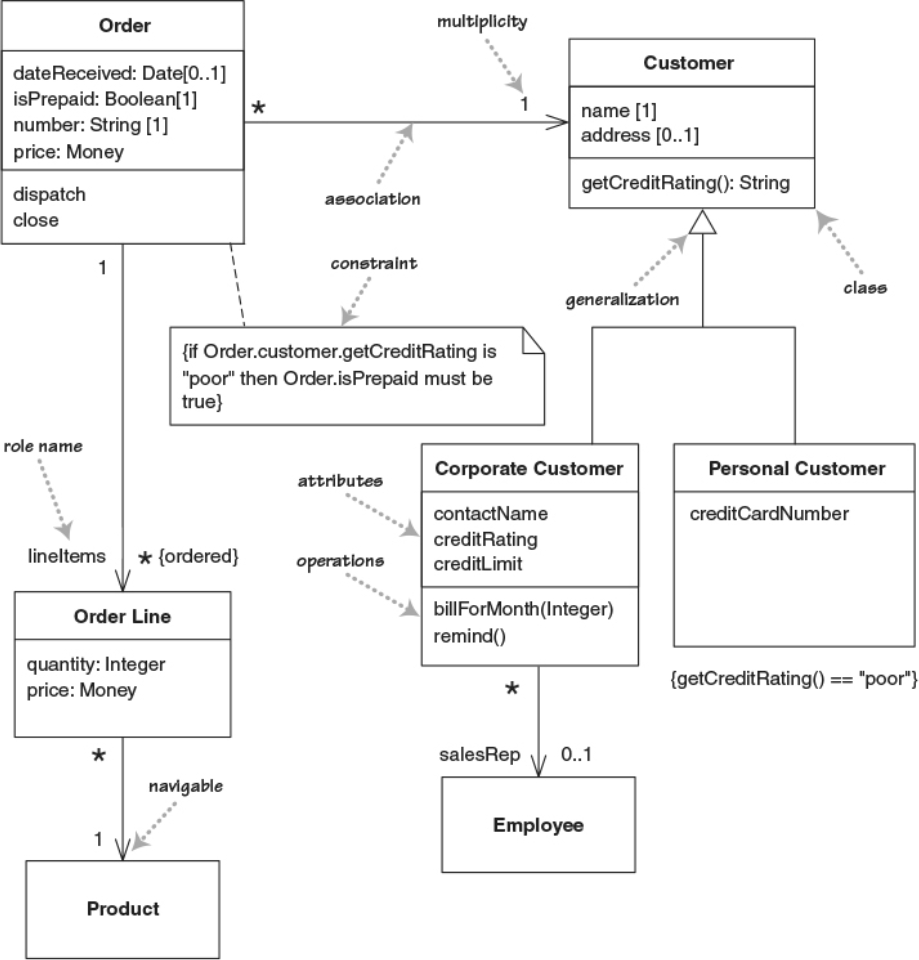

Order processing

# Core Elements

| Concept | Description | Example |
| --- | --- | --- |
| **Class** | Blueprint for objects | `Book`, `Student` |
| **Attribute** | Property of a class | `title: String`, `age: Integer` |
| **Operation** | Behavior of a class | `borrowBook()`, `calculateFine()` |
| **Visibility** | Access modifier | `+ public` |
|  |  | `- private` |
|  |  | `# protected` |
|  |  | `~ package` |

Attribute ::= visibility name: type multiplicity = default {props}

Operation ::= visibility name(parameter-list): return-type {props}

Parameter ::= direction name: type = default_value

# Associations

- Represent *relationships* between classes
- Can have:
  - **Roles**: names describing relationship ends
  - **Multiplicity**: number of instances
  - **Navigability**: direction of the relationship

**Properties vs Associations:**

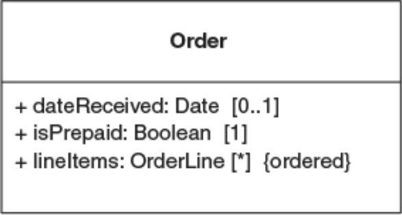

Properties

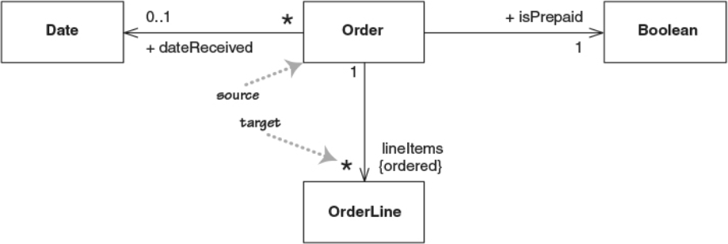

Associations

# Bidirectional Associations

- Pair of properties which are linked together as inverses

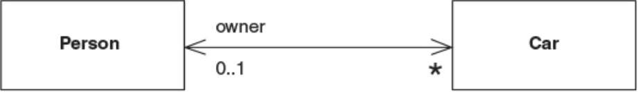

A bidirectional association

If I start with a car, take its `owner`, then take the `cars` property of the owner, then I should find the original car among those cars.

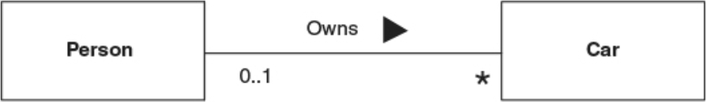

Another way to show a bidirectional association

# Aggregation vs Composition

- **Aggregation ($◇$)**: “has-a” relationship, but parts can exist independently

[figure not shown]

- **Composition ($⬧$)**: “owns-a” relationship, parts die with the whole

[figure not shown]

# Generalization and Interfaces

- **Generalization:** inheritance between classes

[figure not shown]

- **Implementation** of an interface

[figure not shown]

# Dependencies

- A dependency exists between two elements if
  - changes to the definition of one element (the supplier or target)
  - may cause changes to the other (the client or source).
- Indicated with a dashed arrow

[figure not shown]

# Example – Interfaces and abstract classes in Java

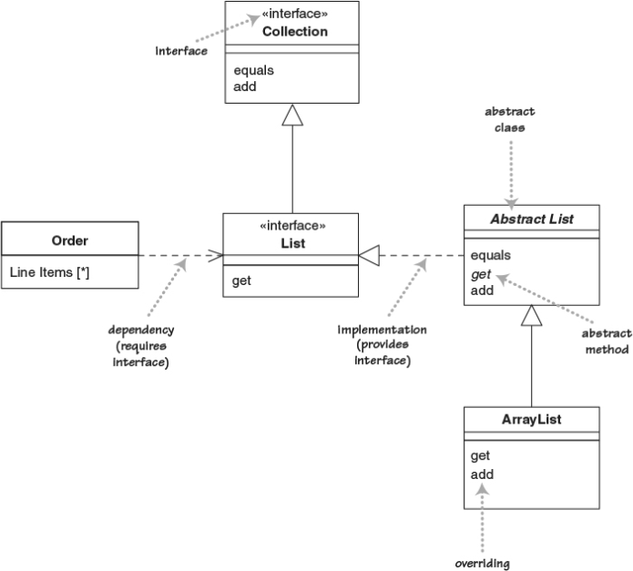

Interfaces and abstract classes in Java – expanded view

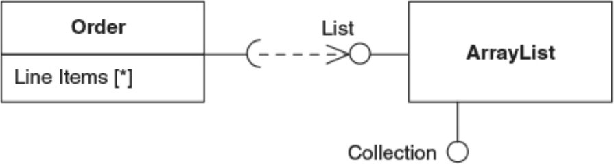

Interfaces and abstract classes in Java – ball-and-socket view

# Interactive Exercise 1: Spot the Elements

```
Class: Library
 - name: String
 - books: List<Book>
 + addBook(b: Book)
 + findBook(title: String): Book

Class: Book
 - title: String
 - author: String
 + borrow()
 + return()
```

**Task (5 minutes):** Identify classes, attributes, operations, and their relationships.

# Design Heuristics & Good Practices

- Favor composition over inheritance
- Keep diagrams readable (<20 classes per diagram)
- Use consistent naming conventions
- Model only what’s necessary
- Document assumptions and constraints

# Example – over-complicated diagram

[figure not shown]

# Example – Simplified (conceptual) diagram

[figure not shown]

# Interactive Exercise 2: Build a Class Diagram

**Scenario:** Online food delivery system.

- Entities: `Customer`, `Restaurant`, `Order`, `MenuItem`, `DeliveryDriver`
- Operations: place order, assign driver, calculate total

**Task (15 minutes):**

- Form small groups
- Sketch a class diagram
- Show associations, multiplicities, and at least one inheritance relationship

**Then:** Present and discuss different design choices.

# Wrap-Up

**Today’s takeaways:**

- Class diagrams model the structure of systems
- Associations and multiplicities matter
- Composition, inheritance, and dependencies define relationships
- Modeling requires balance: detail vs. clarity

**Next class:** requirements analysis